# FigureYa264epiImmune

# 开始画图

# Plotting

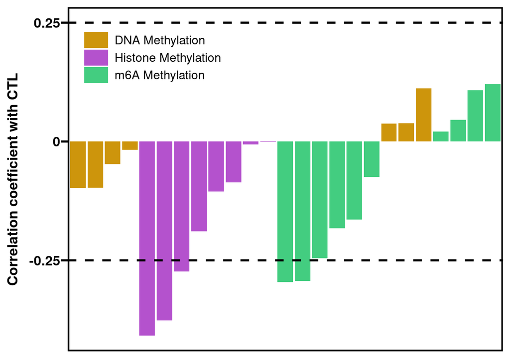

```r
# 相关性柱状图绘制
# Correlation Barplot Visualization
ggplot(cor_df, aes(x = gene, y = CTL, fill = type)) +
  geom_col() +
  geom_hline(yintercept = c(-0.25, 0.25), lwd = 1, lty = 2) +
  scale_y_continuous(breaks = c(-0.25, 0, 0.25),
                     labels = c("-0.25", "0", "0.25")) +
  scale_x_discrete(limits = cor_df %>% arrange(group, type, CTL) %$% gene) +

  # 设置填充色标尺（三种甲基化类型）
  # Set fill color scale (three methylation types)
  scale_fill_manual(labels = c("DNA Methylation", "Histone Methylation", "m6A Methylation"),
                    values = c("darkgoldenrod3", "mediumorchid3", "seagreen3")) +

  # 坐标轴标签设置
  # Axis labels settings
  xlab(NULL) +
  ylab("Correlation coefficient with CTL") +

  # 使用prism主题（仿GraphPad风格）
  # Use prism theme (GraphPad style)
  theme_prism() +

  # 自定义主题元素
  # Custom theme elements
  theme(panel.border = element_rect(fill=NA, color="black", size=1.5, linetype="solid"),
        axis.line = element_line(size = 0),
        axis.ticks.x = element_blank(),
        axis.text.x = element_blank(),
        legend.position = c(0.02, 0.95), legend.justification = c(0, 1),
        legend.text = element_text(size = 12)) -> p
p
```

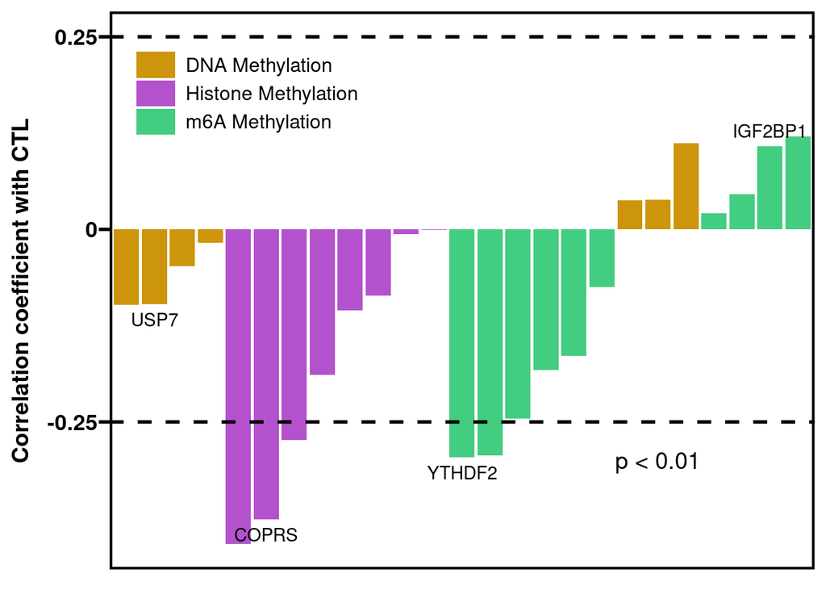

```r
# 以下代码可用于在图中添加文字，也可以忽略代码，手动添加
# 写pvalue，根据自己的数据调整位置
# Optional gene labeling (can also add manually in Illustrator)
# Add p-value annotation (adjust position as needed)
p + annotate("text", x = 20, y = -0.3,
           label = "p < 0.01", size = 5) +
  geom_text(data = subset(cor_df, gene == "USP7"),
            aes(gene, CTL - 0.02,label = "USP7")) +
  geom_text(data = subset(cor_df, gene == "COPRS"),
            aes(gene, CTL - 0.02,label = "COPRS")) +
  geom_text(data = subset(cor_df, gene == "YTHDF2"),
            aes(gene, CTL - 0.02,label = "YTHDF2")) +
  geom_text(data = subset(cor_df, gene == "IGF2BP1"),
            aes(gene, CTL + 0.02,label = "IGF2BP1"))
```

```r
# 保存为PDF
# Save as PDF
ggsave("epiImmune.pdf", width = 6, height = 4)
```

# 后期处理

# Post-processing

输出的PDF文件是矢量图，可以用Illustrator等矢量图编辑器打开，把图中文字改为斜体，调整左右两侧基因名的位置。或者干脆手动添加想要显示的基因名。

The output PDF file is a vector graphic, which can be opened in vector editing software like Illustrator. You can modify the text in the figure to italics and adjust the positions of gene names on both sides. Alternatively, you can manually add the desired gene names.

# 会话信息